# Supervised Learning Regression Project: Cars4U

**Submitted by: Larry Weatherford on June 9, 2023**

## Problem Statement

### Business Context

There is a huge demand for used cars in the Indian Market today. As sales of new cars have slowed down in the recent past, the pre-owned car market has continued to grow over the past years and is larger than the new car market now. Cars4U is a budding tech start-up that aims to find footholes in this market.

In 2018-19, while new car sales were recorded at 3.6 million units, around 4 million second-hand cars were bought and sold. There is a slowdown in new car sales and that could mean that the demand is shifting towards the pre-owned market. In fact, some car sellers replace their old cars with pre-owned cars instead of buying new ones. Unlike new cars, where price and supply are fairly deterministic and managed by OEMs (Original Equipment Manufacturer / except for dealership level discounts which come into play only in the last stage of the customer journey), used cars are very different beasts with huge uncertainty in both pricing and supply. Keeping this in mind, the pricing scheme of these used cars becomes important in order to grow in the market.

As a senior data scientist at Cars4U, you have to come up with a pricing model that can effectively predict the price of used cars and can help the business in devising profitable strategies using differential pricing. For example, if the business knows the market price, it will never sell anything below it.

### Objective

To explore and visualize the dataset, build a linear regression model to predict the prices of used cars, and generate a set of insights and recommendations that will help the business.

### Data Description

The data contains the different attributes of used cars sold in different locations. The detailed data dictionary is given below.

**Data Dictionary**

- S.No.: Serial number
- Name: Name of the car which includes brand name and model name
- Location: Location in which the car is being sold or is available for purchase (cities)
- Year: Manufacturing year of the car
- Kilometers_driven: The total kilometers driven in the car by the previous owner(s) in km
- Fuel_Type: The type of fuel used by the car (Petrol, Diesel, Electric, CNG, LPG)
- Transmission: The type of transmission used by the car (Automatic/Manual)
- Owner_Type: Type of ownership
- Mileage: The standard mileage offered by the car company in kmpl or km/kg
- Engine: The displacement volume of the engine in CC
- Power: The maximum power of the engine in bhp
- Seats: The number of seats in the car
- New_Price: The price of a new car of the same model in INR Lakhs (1 Lakh = 100,000 INR)
- Price: The price of the used car in INR Lakhs

## Importing necessary libraries

```python
# installing black to help with auto code formattting -q will suppress the loading messages
!pip install -q black

from pathlib import Path
from black import WriteBack, Report, Mode, reformat_code, TargetVersion, reformat_one#

# Libraries to help with reading and manipulating data
import numpy as np
import pandas as pd
import re
from scipy import stats

# Libraries to help with data visualization
from IPython.display import display, HTML
import matplotlib.pyplot as plt
import seaborn as sns
sns.set()

# Removes the limit for the number of displayed columns & Set limit to display
pd.set_option("display.max_columns", None)
pd.set_option("display.max_rows", 200)

# To split the data into train and test
from sklearn.model_selection import train_test_split

# To build linear regression_model
from sklearn.linear_model import LinearRegression

# To check model performance
from sklearn.metrics import mean_absolute_error, mean_squared_error, r2_score
from tabulate import tabulate

# For date arithmatic
import datetime
```

## Define the necessary functions for this project

```python
# Histogram and Boxplot for univarient features
def histbox(df, column, figsize=(12, 7), kde=False, bins=None):
    """
    Histogram and Boxplot

    df: dataframe
    column: dataframe column
    figsize: size of figure (default (12,7))
    kde: whether to show the density curve (default False)
    bins: number of bins for histogram (default None)
    """
    f, (ax_box, ax_hist) = plt.subplots(
        nrows=2,  # Number of rows of the subplot grid = 2
        sharex=True,  # x-axis will be shared among all subplots
        gridspec_kw={"height_ratios": (0.25, 0.75)},
        figsize=figsize,
    )  # creating the 2 subplots
    sns.boxplot(
        data=df, x=column, ax=ax_box, showmeans=True, color="orange"
    )  # boxplot will be created and a star will indicate the mean value of the column
    sns.histplot(
        data=df, x=column, kde=kde, ax=ax_hist, bins=bins, palette="winter"
    ) if bins else sns.histplot(
        data=df, x=column, kde=kde, ax=ax_hist
    )  # For histogram
    ax_hist.axvline(
        df[column].mean(), color="green", linestyle="--"
    )  # Add mean to the histogram
    ax_hist.axvline(df[column].median(), color="blue", linestyle="-")
    ax_hist.set_title(column, fontsize=20, fontweight='bold')  # Set title with underline
    ax_hist.set_xlabel(column, fontsize=15)  # Set xlabel

    plt.tight_layout()
    plt.show()  # show the plot
```

## Loading the dataset

```python
# mount drive for working in colab
from google.colab import drive
drive.mount('/content/drive')
```

```python
# loading the dataset and copy the data to a new df named 'cars'
cars = pd.read_csv('/content/drive/MyDrive/Projects/Cars4U/used_cars_data.csv')
```

## Data Overview

- Observations
- Sanity checks

```python
# Check the shape of the data
print(f"There are {cars.shape[0]} rows and {cars.shape[1]} columns.")
```

```
There are 7253 rows and 14 columns.
```

```python
# Checking the info of the cars data
cars.info()
```

```
<class 'pandas.core.frame.DataFrame'>
RangeIndex: 7253 entries, 0 to 7252
Data columns (total 14 columns):
 #   Column             Non-Null Count  Dtype
---  ------             --------------  -----
 0   S.No.              7253 non-null   int64
 1   Name               7253 non-null   object
 2   Location           7253 non-null   object
 3   Year               7253 non-null   int64
 4   Kilometers_Driven  7253 non-null   int64
 5   Fuel_Type          7253 non-null   object
 6   Transmission       7253 non-null   object
 7   Owner_Type         7253 non-null   object
 8   Mileage            7251 non-null   object
 9   Engine             7207 non-null   object
 10  Power              7078 non-null   object
 11  Seats              7200 non-null   float64
 12  New_Price          7253 non-null   float64
 13  Price              6019 non-null   float64
dtypes: float64(3), int64(3), object(8)
memory usage: 793.4+ KB
```

**Observations:**

1. 7253 entries.
2. Engine, Power, Seats, and Price have missing values.

```python
# Checking the statistics of the data
cars.describe(include='all').T
```

|  | count | unique | top | freq | mean | std | min | 25% | 50% | 75% | max |
| --- | --- | --- | --- | --- | --- | --- | --- | --- | --- | --- | --- |
| S.No. | 7253.0 | NaN | NaN | NaN | 3626.0 | 2093.905084 | 0.0 | 1813.0 | 3626.0 | 5439.0 | 7252.0 |
| Name | 7253 | 2041 | Mahindra XUV500 W8 2WD | 55 | NaN | NaN | NaN | NaN | NaN | NaN | NaN |
| Location | 7253 | 11 | Mumbai | 949 | NaN | NaN | NaN | NaN | NaN | NaN | NaN |
| Year | 7253.0 | NaN | NaN | NaN | 2013.365366 | 3.254421 | 1996.0 | 2011.0 | 2014.0 | 2016.0 | 2019.0 |
| Kilometers_Driven | 7253.0 | NaN | NaN | NaN | 58699.063146 | 84427.720583 | 171.0 | 34000.0 | 53416.0 | 73000.0 | 6500000.0 |
| Fuel_Type | 7253 | 5 | Diesel | 3852 | NaN | NaN | NaN | NaN | NaN | NaN | NaN |
| Transmission | 7253 | 2 | Manual | 5204 | NaN | NaN | NaN | NaN | NaN | NaN | NaN |
| Owner_Type | 7253 | 4 | First | 5952 | NaN | NaN | NaN | NaN | NaN | NaN | NaN |
| Mileage | 7251 | 450 | 17.0 kmpl | 207 | NaN | NaN | NaN | NaN | NaN | NaN | NaN |
| Engine | 7207 | 150 | 1197 CC | 732 | NaN | NaN | NaN | NaN | NaN | NaN | NaN |
| Power | 7078 | 385 | 74 bhp | 280 | NaN | NaN | NaN | NaN | NaN | NaN | NaN |
| Seats | 7200.0 | NaN | NaN | NaN | 5.279722 | 0.81166 | 0.0 | 5.0 | 5.0 | 5.0 | 10.0 |
| New_Price | 7253.0 | NaN | NaN | NaN | 21.307322 | 24.256314 | 3.91 | 7.88 | 11.3 | 21.69 | 375.0 |
| Price | 6019.0 | NaN | NaN | NaN | 9.479468 | 11.187917 | 0.44 | 3.5 | 5.64 | 9.95 | 160.0 |

**Observations:**

**Questions:**

1. Why is Kilos Driven max so high. Is that an outlier?
2. Why is Seats Min a zero? Seems like an error.
3. Should we strip Mileage, Engine, and Power of non-numerica chars?

```python
# Examining the first 5 rows of data as part of sanity check
cars.head()
```

|  | S.No. | Name | Location | Year | Kilometers_Driven | Fuel_Type | Transmission | Owner_Type | Mileage | Engine | Power | Seats | New_Price | Price |
| --- | --- | --- | --- | --- | --- | --- | --- | --- | --- | --- | --- | --- | --- | --- |
| 0 | 0 | Maruti Wagon R LXI CNG | Mumbai | 2010 | 72000 | CNG | Manual | First | 26.6 km/kg | 998 CC | 58.16 bhp | 5.0 | 5.51 | 1.75 |
| 1 | 1 | Hyundai Creta 1.6 CRDi SX Option | Pune | 2015 | 41000 | Diesel | Manual | First | 19.67 kmpl | 1582 CC | 126.2 bhp | 5.0 | 16.06 | 12.50 |
| 2 | 2 | Honda Jazz V | Chennai | 2011 | 46000 | Petrol | Manual | First | 18.2 kmpl | 1199 CC | 88.7 bhp | 5.0 | 8.61 | 4.50 |
| 3 | 3 | Maruti Ertiga VDI | Chennai | 2012 | 87000 | Diesel | Manual | First | 20.77 kmpl | 1248 CC | 88.76 bhp | 7.0 | 11.27 | 6.00 |
| 4 | 4 | Audi A4 New 2.0 TDI Multitronic | Coimbatore | 2013 | 40670 | Diesel | Automatic | Second | 15.2 kmpl | 1968 CC | 140.8 bhp | 5.0 | 53.14 | 17.74 |

**Observations:**

1. The S.No. column is of no value to us so we will drop it in data preprosessing.
2. The name column has the Brand and Model so we will split these out as seperate columns and drop the name. Land Rover will be changed to Land-Rover.
3. The other columns' data look straightforward so far with the exceptions of Mileage, Engine, and Power. These have unnecessary non-numeric data (kmpl, bhp, CC) that we will strip out and convert those columns to float.

```python
# Dropping the S.No. Columns as it provides no value to us
cars.drop("S.No.", axis=1, inplace=True)

# Extract Brand and Model info from Name column and place into 2 new columns
cars['Name'] = cars['Name'].str.replace('Land Rover', 'Land-Rover')
cars['Brand'] = cars['Name'].str.split(' ', n=1, expand=True)[0].astype('category')
cars['Model'] = cars['Name'].str.split(' ', n=1, expand=True)[1].astype('category')
cars.drop(['Name'], axis=1, inplace=True)

# Strip out non-numeric characters from Mileage column and covert column to float
cars['Mileage'] = cars['Mileage'].str.replace(r'\D', '', regex=True)
cars['Mileage'] = cars['Mileage'].astype(float)

# Strip out non-numeric characters from Power column and covert column to float
cars['Power'] = cars['Power'].str.replace(r'\D', '', regex=True)
cars['Power'] = cars['Power'].astype(float)

# Strip out non-numeric characters from Engine column and covert column to float
cars['Engine'] = cars['Engine'].str.replace(r'\D', '', regex=True)
cars['Engine'] = cars['Engine'].astype(float)
```

```python
cars.info()
```

```
<class 'pandas.core.frame.DataFrame'>
RangeIndex: 7253 entries, 0 to 7252
Data columns (total 14 columns):
 #   Column             Non-Null Count  Dtype
---  ------             --------------  -----
 0   Location           7253 non-null   object
 1   Year               7253 non-null   int64
 2   Kilometers_Driven  7253 non-null   int64
 3   Fuel_Type          7253 non-null   object
 4   Transmission       7253 non-null   object
 5   Owner_Type         7253 non-null   object
 6   Mileage            7251 non-null   float64
 7   Engine             7207 non-null   float64
 8   Power              7078 non-null   float64
 9   Seats              7200 non-null   float64
 10  New_Price          7253 non-null   float64
 11  Price              6019 non-null   float64
 12  Brand              7253 non-null   category
 13  Model              7253 non-null   category
dtypes: category(2), float64(6), int64(2), object(4)
memory usage: 783.1+ KB
```

**Oberservations:**

```python
cars.head()
```

|  | Location | Year | Kilometers_Driven | Fuel_Type | Transmission | Owner_Type | Mileage | Engine | Power | Seats | New_Price | Price | Brand | Model |
| --- | --- | --- | --- | --- | --- | --- | --- | --- | --- | --- | --- | --- | --- | --- |
| 0 | Mumbai | 2010 | 72000 | CNG | Manual | First | 266.0 | 998.0 | 5816.0 | 5.0 | 5.51 | 1.75 | Maruti | Wagon R LXI CNG |
| 1 | Pune | 2015 | 41000 | Diesel | Manual | First | 1967.0 | 1582.0 | 1262.0 | 5.0 | 16.06 | 12.50 | Hyundai | Creta 1.6 CRDi SX Option |
| 2 | Chennai | 2011 | 46000 | Petrol | Manual | First | 182.0 | 1199.0 | 887.0 | 5.0 | 8.61 | 4.50 | Honda | Jazz V |
| 3 | Chennai | 2012 | 87000 | Diesel | Manual | First | 2077.0 | 1248.0 | 8876.0 | 7.0 | 11.27 | 6.00 | Maruti | Ertiga VDI |
| 4 | Coimbatore | 2013 | 40670 | Diesel | Automatic | Second | 152.0 | 1968.0 | 1408.0 | 5.0 | 53.14 | 17.74 | Audi | A4 New 2.0 TDI Multitronic |

**Observations:**

```python
# Let's examine the statisical data now that he data has been cleaned up some
cars.describe().T
```

|  | count | mean | std | min | 25% | 50% | 75% | max |
| --- | --- | --- | --- | --- | --- | --- | --- | --- |
| Year | 7253.0 | 2013.365366 | 3.254421 | 1996.00 | 2011.00 | 2014.00 | 2016.00 | 2019.0 |
| Kilometers_Driven | 7253.0 | 58699.063146 | 84427.720583 | 171.00 | 34000.00 | 53416.00 | 73000.00 | 6500000.0 |
| Mileage | 7251.0 | 854.206454 | 860.930796 | 0.00 | 173.00 | 229.00 | 1701.00 | 3354.0 |
| Engine | 7207.0 | 1616.573470 | 595.285137 | 72.00 | 1198.00 | 1493.00 | 1968.00 | 5998.0 |
| Power | 7078.0 | 2768.196948 | 5139.461835 | 35.00 | 140.00 | 838.00 | 1685.00 | 108495.0 |
| Seats | 7200.0 | 5.279722 | 0.811660 | 0.00 | 5.00 | 5.00 | 5.00 | 10.0 |
| New_Price | 7253.0 | 21.307322 | 24.256314 | 3.91 | 7.88 | 11.30 | 21.69 | 375.0 |
| Price | 6019.0 | 9.479468 | 11.187917 | 0.44 | 3.50 | 5.64 | 9.95 | 160.0 |

**Questions:**

1. Why is Kilos Driven max so high. Is that an outlier?
2. Why is Seats Min a zero? Seems like an error.
3. Why is the Max Price so high compared to the mean and avg?

```python
# checking for duplicate values in the data
cars.duplicated().sum()
```

```
1
```

```python
# There was 1 duplicat row so we are dropping it now
cars.drop_duplicates(inplace=True)
```

```python
# checking for duplicate values in the data
cars.duplicated().sum()
```

```
0
```

**Verified there are no duplicates**

## Data Preprocessing

```python
# Check for missing values in the DataFrame
cars.isnull().sum()
```

```
Location                0
Year                    0
Kilometers_Driven       0
Fuel_Type               0
Transmission            0
Owner_Type              0
Mileage                 2
Engine                 46
Power                 175
Seats                  53
New_Price               0
Price                1233
Brand                   0
Model                   0
dtype: int64
```

**Observations: Mileage, Engine, Power, Seats and Price have missing values and we will deal with these Columns**

## Mileage, Engine and Power feature evaluation and treatment

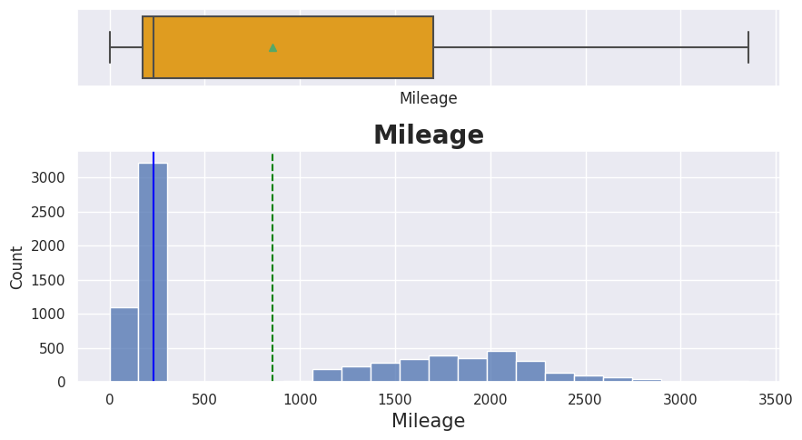

```python
histbox(cars, "Mileage",figsize=(9, 5))
```

**Observations:** Mileage doesn't have outliers. It has only 2 missing values so we will impute them with the median since the data is mostly right skewed.

```python
# Impute the missing values in the "Mileage" column with the median
cars['Mileage'].fillna(cars['Mileage'].median(), inplace=True)
```

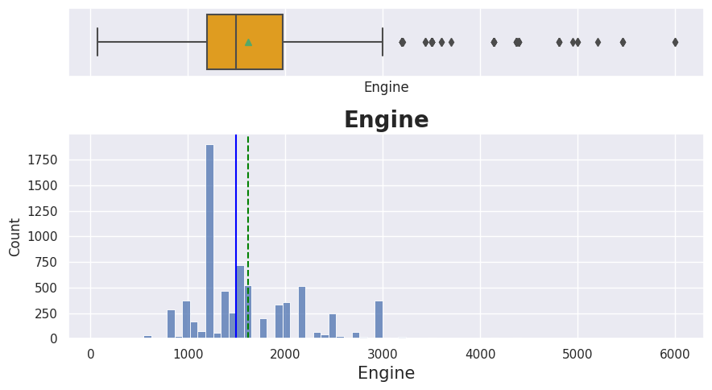

```python
histbox(cars, 'Engine',figsize=(9, 5))
```

**Observations:** Engine has outliers we need to evaluate. It has 46 missing values so we will impute them with the mean since the data is fairly distributed.

```python
# Impute the missing values in the "Engine" column with the mean
cars['Engine'].fillna(cars['Engine'].mean(), inplace=True)
```

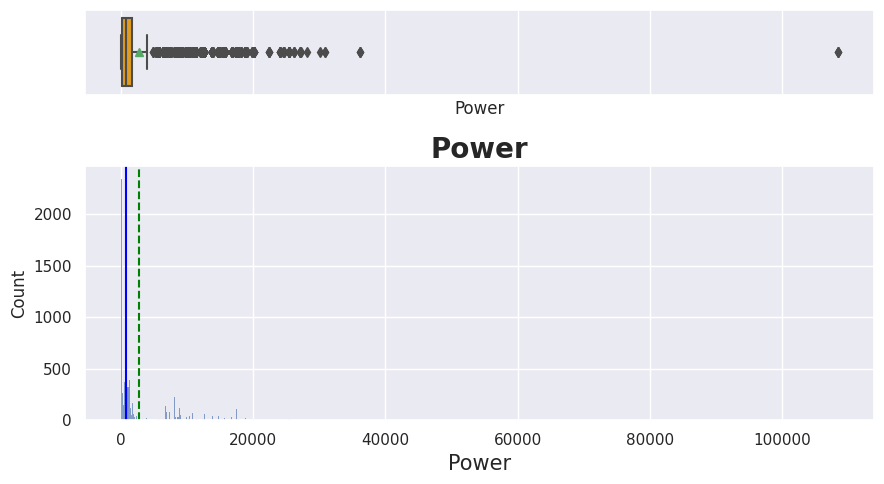

```python
histbox(cars, 'Power',figsize=(9, 5))
```

**Observations:**

1. Power has outliers we need to evaluate.
2. It has 175 missing values that we will impute using the median since the data is right skewed.
3. For some reason the Power is not importing correctly into the dataset. By exporting the data into Excel I could see that the bhp powers are off by orders of magnitude. To correct this data we use this approach: If Power >=5000 divide by 100 else if Power >=500 and <= 5000 divide by 10 This should correct most of the data and bring it in line with realistic bhp

```python
# Replace the missing values in the "Power" column with the median
cars['Power'].fillna(cars['Power'].median(), inplace=True)
```

```python
# Correctly the order of magnitude issues with the Power data
cars.loc[cars['Power'] >= 5000, 'Power'] = cars.loc[cars['Power'] >= 5000, 'Power'] / 100
cars.loc[(cars['Power'] >= 500) & (cars['Power'] < 5000), 'Power'] = cars.loc[(cars['Power'] >= 500) & (cars['Power'] < 5000), 'Power'] / 10

# There are 5 car models that have incorrect bhp.  After verifing the correct bhp these car models were updated as shown below.
cars.loc[cars['Power'] == 473, 'Power'] = 47  #Car Model Maruti Alto 800 LXI
cars.loc[cars['Power'] == 463, 'Power'] = 46  #Car Model Maruti Alto LXi
cars.loc[cars['Power'] == 403, 'Power'] = 40  #Car Model Maruti Alto 800 2016-2019 CNG LXI
cars.loc[cars['Power'] == 375, 'Power'] = 38  #Car Model Tata Nano Twist XT
cars.loc[cars['Power'] == 342, 'Power'] = 34  #Car Model Maruti Omni E
```

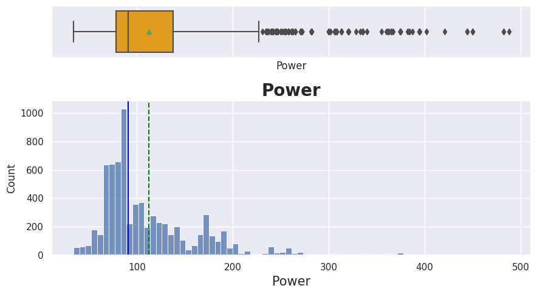

```python
histbox(cars, 'Power',figsize=(9, 5))
```

**Observations:** After adjusting the Power data it has a more normal distribution and the outliers are mostly legit.

```python
cars.isnull().sum()
```

```
Location                0
Year                    0
Kilometers_Driven       0
Fuel_Type               0
Transmission            0
Owner_Type              0
Mileage                 0
Engine                  0
Power                   0
Seats                  53
New_Price               0
Price                1233
Brand                   0
Model                   0
dtype: int64
```

Mileage, Engine, and Power now have no missing values.

## Seats feature evaluation and treatment

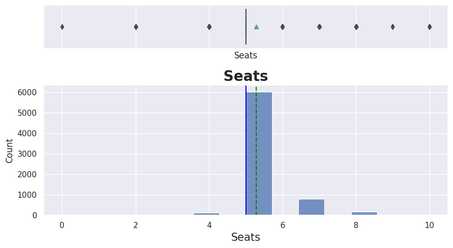

```python
histbox(cars, 'Seats',figsize=(9, 5))
```

```python
# Let's view the Cars with zero seats
print('Cars with Zero Seats:')
cars[cars['Seats']==0.0]
```

```
Cars with Zero Seats:
```

|  | Location | Year | Kilometers_Driven | Fuel_Type | Transmission | Owner_Type | Mileage | Engine | Power | Seats | New_Price | Price | Brand | Model |
| --- | --- | --- | --- | --- | --- | --- | --- | --- | --- | --- | --- | --- | --- | --- |
| 3999 | Hyderabad | 2012 | 125000 | Petrol | Automatic | First | 105.0 | 3197.0 | 83.8 | 0.0 | 53.14 | 18.0 | Audi | A4 3.2 FSI Tiptronic Quattro |

```python
# Change the # of seats for this model to 5
cars.loc[(cars['Model'] == 'A4 3.2 FSI Tiptronic Quattro') & (cars['Brand'] == 'Audi'), 'Seats'] = 5
```

```python
# Replace the missing values in the "Seats" column with the mean
cars['Seats'].fillna(cars['Seats'].mean(), inplace=True)
```

```python
cars['Seats'].describe()
```

```
count    7252.000000
mean        5.280456
std         0.806363
min         2.000000
25%         5.000000
50%         5.000000
75%         5.000000
max        10.000000
Name: Seats, dtype: float64
```

**Explaining the 4 code cells above:** We were able to see that the Audi A4 3.2 FSI Tiptronic Quattro is the only car in the data that has zero seats. Performing a google search we learn that this car has 5 seats. So we replaced the zero instances with 5. The descibe method on the Seats shows the Min Seats is now 2. Finally we use the mean to impute the missing values of Seats since it is right skewed.

Seats doesn't require any further manipulation.

## Price feature evaluation and treatment

```python
# Since Price is the target variable we will drop the missing values and reset the index
cars.dropna(subset=['Price'], inplace=True)
cars.reset_index(inplace=True, drop=True)
```

```python
# Show the top 5 most expensive brands to help determine if the 160 price seems real
top_5_expensive_cars = cars.nlargest(5, 'Price')[['Brand', 'Model', 'Price']]
print(top_5_expensive_cars)
```

```
            Brand                             Model   Price
4079   Land-Rover  Range Rover 3.0 Diesel LWB Vogue  160.00
5781  Lamborghini                    Gallardo Coupe  120.00
5919       Jaguar                   F Type 5.0 V8 S  100.00
1505   Land-Rover              Range Rover Sport SE   97.07
1974          BMW                    7 Series 740Li   93.67
```

**Observations:**

1. Since Price is the target variable it makes sense to drop the rows with missing price values.
2. It seems that the 160 price is for a Land Rover luxury vehicle so we will leave it.

```python
# Show the sum of the missing values for each column
cars.isnull().sum()
```

```
Location             0
Year                 0
Kilometers_Driven    0
Fuel_Type            0
Transmission         0
Owner_Type           0
Mileage              0
Engine               0
Power                0
Seats                0
New_Price            0
Price                0
Brand                0
Model                0
dtype: int64
```

**Now there are no missing values. The data is ready for EDA**

## Exploratory Data Analysis (EDA)

- EDA is an important part of any project involving data.
- It is important to investigate and understand the data better before building a model with it.
- A few questions have been mentioned below which will help you approach the analysis in the right manner and generate insights from the data.
- A thorough analysis of the data, in addition to the questions mentioned below, should be done.

**Questions**:

1. How is the pricing of used cars distributed?
2. What is the market share of different brands in the used car market?
3. What is the market share of different types of fuels in the used car market?
4. How does the prices of used cars vary by car brand?
5. How does the prices of used cars vary by location?
6. What are the attributes that have a strong correlation with the price of used cars?

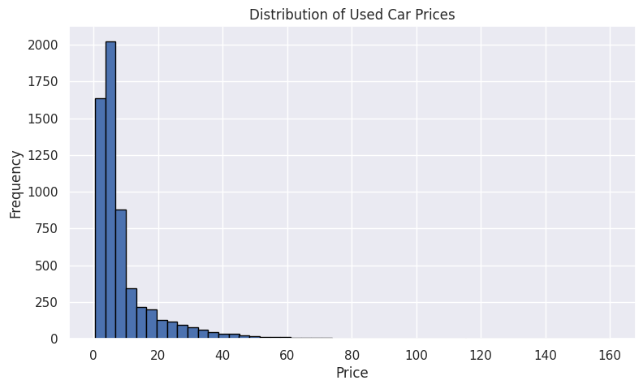

```python
# 1. How is the pricing of used cars distributed?
plt.figure(figsize=(9, 5))
plt.hist(cars['Price'], bins=50, edgecolor='black')
plt.xlabel('Price')
plt.ylabel('Frequency')
plt.title('Distribution of Used Car Prices')
plt.show()
```

**Observations:** Price is right skewed.

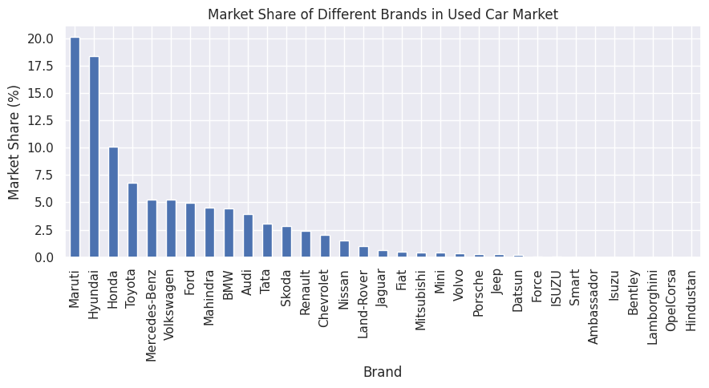

```python
# 2. What is the market share of different brands in the used car market?
# We use a bar plot to visualize the marketshare by Brand
brand_market_share = cars['Brand'].value_counts(normalize=True) * 100

# Plot the market share
plt.figure(figsize=(9, 5))
brand_market_share.plot(kind='bar')
plt.xlabel('Brand')
plt.ylabel('Market Share (%)')
plt.title('Market Share of Different Brands in Used Car Market')
plt.xticks(rotation=90)
plt.tight_layout()
plt.show()
```

```python
# Calculate the sum of unique Brands & models
unique_brands_sum = cars['Brand'].nunique()
unique_models_sum = cars['Model'].nunique()

# Print the sum of each
print("Unique Brands Count:", unique_brands_sum)
print("Unique Models Count:", unique_models_sum)
```

```
Unique Brands Count: 31
Unique Models Count: 1876
```

```python
# Drop the "Model" column to simplify the regression testing
cars = cars.drop("Model", axis=1)

# Fix the case issue with ISUZU
cars['Brand'].replace(['ISUZU', 'Isuzu'], 'Isuzu', inplace=True)
```

**Observations:**

1. Maruti, Hyundai, Honda, and Toyota make up over 50% of the market.
2. There are 31 total Brands. There are 1876 Models and the names of the models are very inconsistent. We will drop the car Model feature as it will simplify the regression testing.

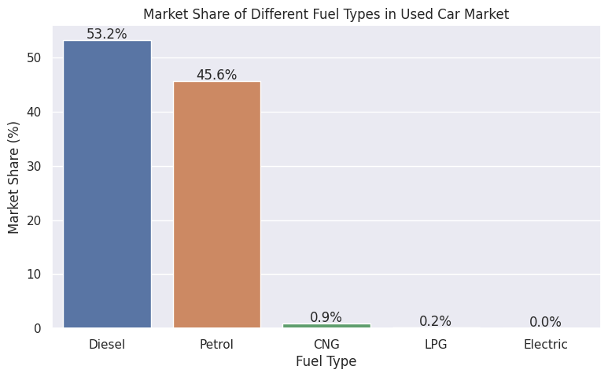

```python
# 3. What is the market share of different types of fuels in the used car market?
# Calculate market share of different fuels
fuel_market_share = cars['Fuel_Type'].value_counts(normalize=True) * 100

# Create bar plot
plt.figure(figsize=(9, 5))
ax = sns.barplot(x=fuel_market_share.index, y=fuel_market_share.values)
plt.xlabel('Fuel Type')
plt.ylabel('Market Share (%)')
plt.title('Market Share of Different Fuel Types in Used Car Market')

# Add percentage labels to each bar
for p in ax.patches:
    ax.annotate(f'{p.get_height():.1f}%', (p.get_x() + p.get_width() / 2., p.get_height()),
                ha='center', va='center', xytext=(0, 5), textcoords='offset points')

plt.show()
```

**Observations:**

The different types of fuels have these market shares: Diesel 53,2%, Petrol 45.6%, CNG 0.9%, LPG - 0.2%, Electric - Not measurable

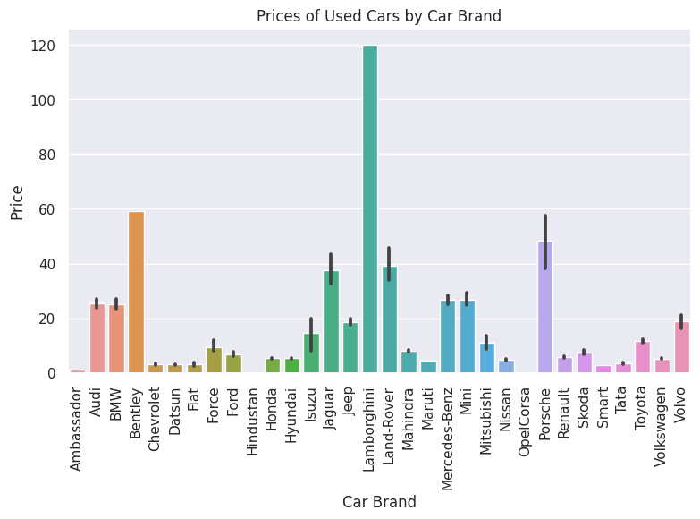

```python
# 4. How does the prices of used cars vary by car brand?
# Use a barplot to show the price vs brand comparison
plt.figure(figsize=(9, 5))
sns.barplot(data=cars, x='Brand', y='Price')
plt.xticks(rotation=90)
plt.xlabel('Car Brand')
plt.ylabel('Price')
plt.title('Prices of Used Cars by Car Brand')
plt.show()
```

**Observations:** Graph showing the car prices by car brand. Lamborghini, Bentley and Porsche are the only brands over 40. Marjority of brands are under 20.

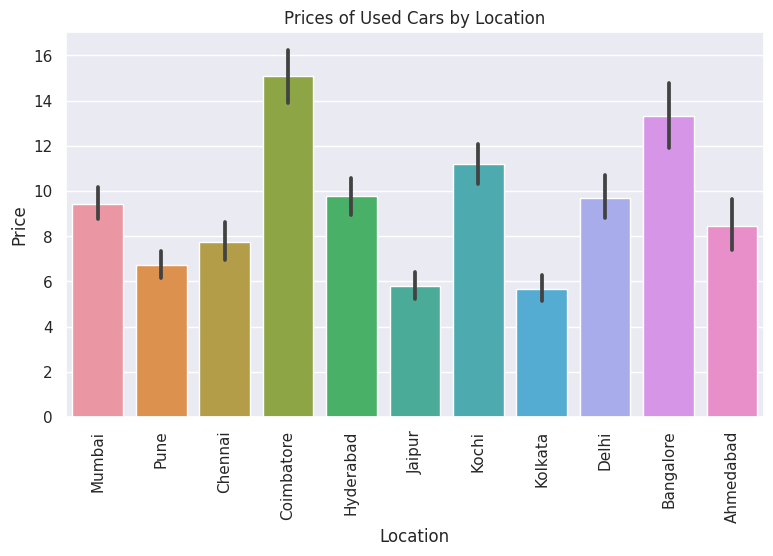

```python
# 5. How does the prices of used cars vary by location?
# Use a barplot to show the price vs location comparison
plt.figure(figsize=(9, 5))
sns.barplot(data=cars, x='Location', y='Price')
plt.xticks(rotation=90)
plt.xlabel('Location')
plt.ylabel('Price')
plt.title('Prices of Used Cars by Location')
plt.show()
```

**Observations:** Price by Location is fairly evenly distributed with the highest prices in Coimbatore, Bangalore, and Kochi. Lowest prices found in Kolkata and Jaipur.

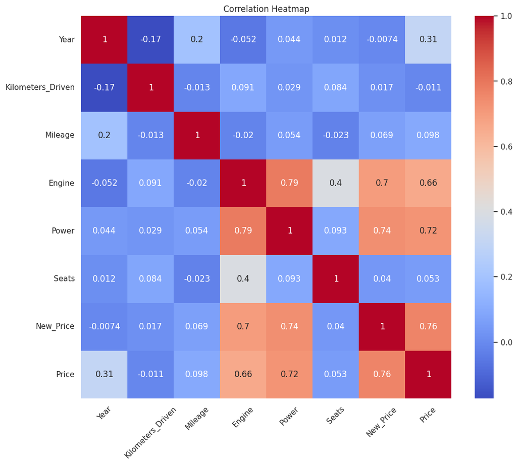

```python
# 6. What are the attributes that have a strong correlation with the price of used cars?
# We will use a heatmap to show all the numeric correlations between features

# Select only the numeric columns
numeric_cols = cars.select_dtypes(include='number')

# Calculate the correlation matrix
corr_matrix = numeric_cols.corr()

# Create a heatmap
plt.figure(figsize=(12, 10))
sns.heatmap(corr_matrix, annot=True, cmap="coolwarm")
plt.title("Correlation Heatmap")

# Rotate the x-axis labels for better visibility
plt.xticks(rotation=45)

# Show the plot
plt.show()
```

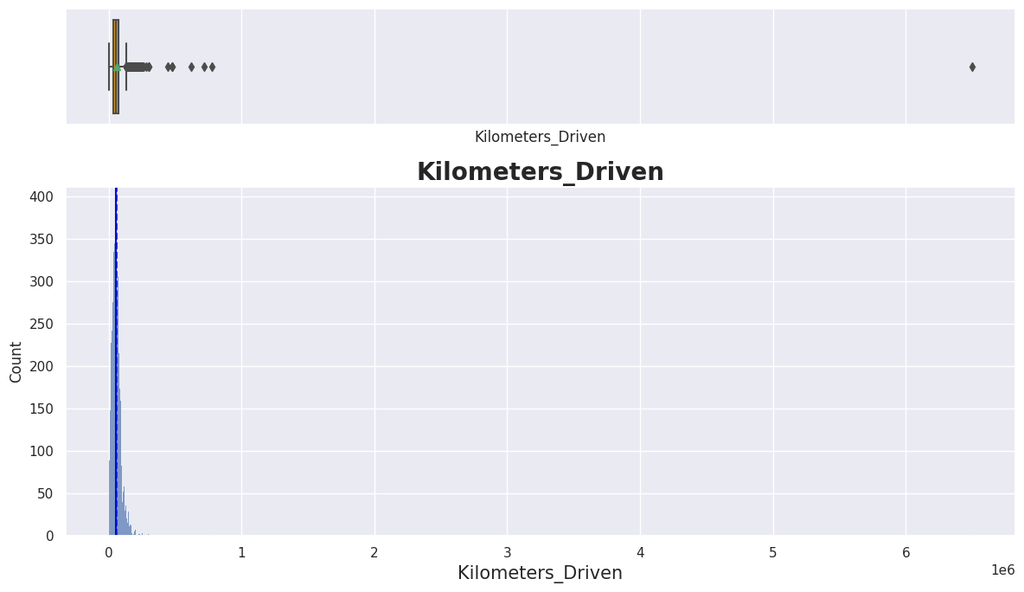

```python
histbox(cars,"Kilometers_Driven")
```

**Observations:**

1. Kilometers_Driver is right skewed and has outliers.
2. Looking at the cars with most kilos driven, we can see there are 7 outliers with over 300,000 kilos. Those seem unrealistic and we will replace any over 300,000 with the mean.

```python
# Show the cars with most Kilos Driven
top_kilo_cars = cars.nlargest(10, 'Kilometers_Driven')
print(top_kilo_cars)
```

```
       Location  Year  Kilometers_Driven Fuel_Type Transmission Owner_Type  \
2328    Chennai  2017            6500000    Diesel    Automatic      First
340     Kolkata  2013             775000    Diesel    Automatic      First
1860    Chennai  2013             720000    Diesel       Manual      First
358     Chennai  2009             620000    Petrol       Manual      First
2823    Chennai  2015             480000    Diesel    Automatic      First
3092    Kolkata  2015             480000    Petrol       Manual      First
4491  Bangalore  2013             445000    Petrol       Manual      First
3649     Jaipur  2008             300000    Diesel       Manual      First
1528  Hyderabad  2005             299322    Diesel       Manual      First
1975       Pune  2012             282000    Petrol       Manual      First

      Mileage  Engine   Power  Seats  New_Price  Price       Brand
2328   1597.0  2993.0  258.00    5.0      55.07  65.00         BMW
340     193.0  1968.0  141.00    5.0      25.83   7.50       Skoda
1860   2054.0  1598.0  103.60    5.0      13.23   5.90  Volkswagen
358    2036.0  1197.0   78.90    5.0      10.25   2.70     Hyundai
2823   1696.0  1968.0  138.03    5.0      10.15  13.00  Volkswagen
3092    174.0  1497.0  117.30    5.0      13.58   5.00       Honda
4491    185.0  1197.0   82.90    5.0      10.25   4.45     Hyundai
3649    170.0  1405.0   70.00    5.0       7.63   1.00        Tata
1528    128.0  2494.0  102.00    8.0      24.01   4.00      Toyota
1975   1314.0  1798.0  160.00    5.0      33.36   3.30       Skoda
```

```python
# Impute the mean for all cars with Kilos Driven over 300,000
average_kilometers = cars['Kilometers_Driven'].mean()
cars.loc[cars['Kilometers_Driven'] > 300000, 'Kilometers_Driven'] = average_kilometers
```

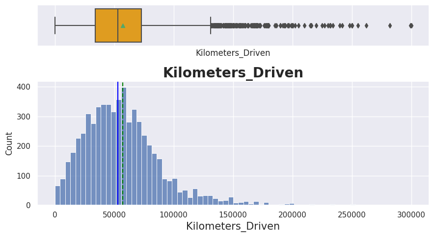

```python
histbox(cars,"Kilometers_Driven",figsize=(9, 5))
```

**Observations:**

1. After the treatment of the major outliers the Kilometers Driven data looks better distributed but the scale is still very large.
2. We will try Log Transformation to see if it helps with scaling.

```python
# Using log transformation on the Price column to help with scaling
cars['Kilometers_Driven_log'] = np.log(cars['Kilometers_Driven'])
```

```python
# Dropping the original column
cars['Kilometers_Driven_log'] = np.log(cars['Kilometers_Driven'])
cars = cars.drop('Kilometers_Driven', axis=1)
```

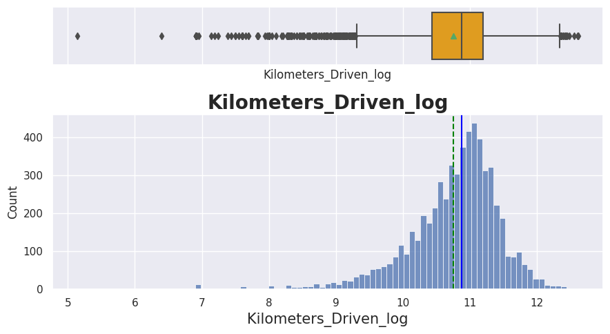

```python
histbox(cars,"Kilometers_Driven_log",figsize=(9, 5))
```

**Observations:** Log Transformation seems to have helped reduce the scale for Kilometers Driven.

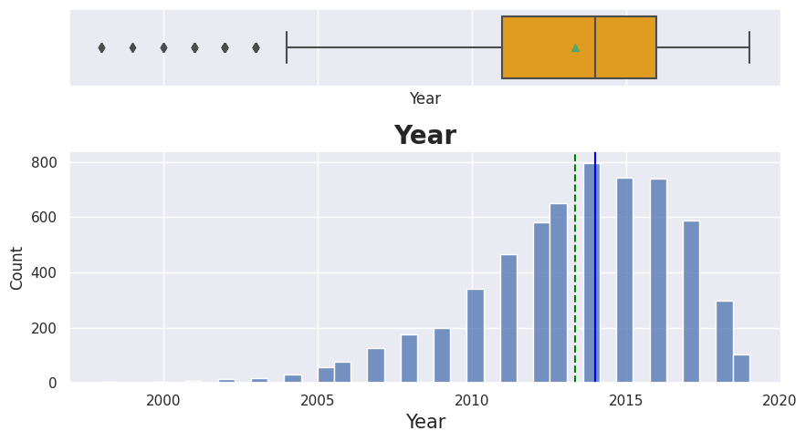

```python
histbox(cars, 'Year',figsize=(9, 5))
```

**Observations:** Year is left skewed. Since the oldest outlier is 1998 it seems feasble that these outliers are legit.

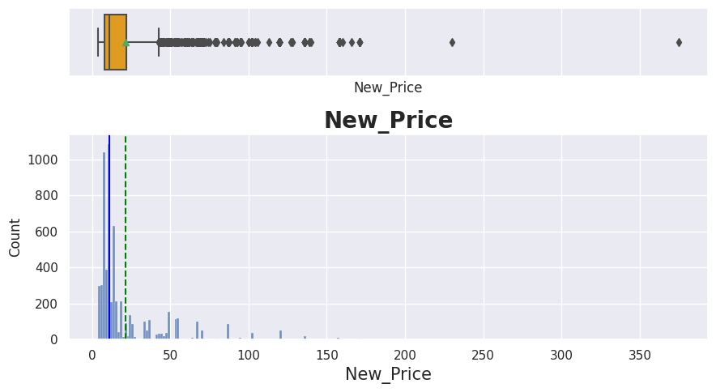

```python
histbox(cars, 'New_Price',figsize=(9, 5))
```

```python
# Examine outliers by looking at most expensive new cars.
top_highest_price_cars = cars.nlargest(5, 'New_Price')
print(top_highest_price_cars)
```

```
        Location  Year Fuel_Type Transmission Owner_Type  Mileage  Engine  \
5521   Hyderabad  2006    Petrol    Automatic      First     86.0  5998.0
4079   Hyderabad  2017    Diesel    Automatic      First   1333.0  2993.0
3939      Mumbai  2006    Petrol       Manual      First    130.0  2987.0
4143     Chennai  2003    Petrol    Automatic      First    130.0  2987.0
4245  Coimbatore  2007    Petrol       Manual      First    130.0  2987.0

      Power  Seats  New_Price   Price          Brand  Kilometers_Driven_log
5521   55.2    4.0      375.0   59.00        Bentley              10.778956
4079  255.0    5.0      230.0  160.00     Land-Rover              10.126631
3939  210.0    5.0      171.0   10.75  Mercedes-Benz              10.308953
4143  210.0    5.0      171.0    6.50  Mercedes-Benz              11.617285
4245  210.0    5.0      171.0   17.09  Mercedes-Benz              11.340273
```

**Observations:**

```python
# Performing Log Transformation on Price_Log
cars['New_Price_log'] = np.log(cars['New_Price'])
cars = cars.drop('New_Price', axis=1)
```

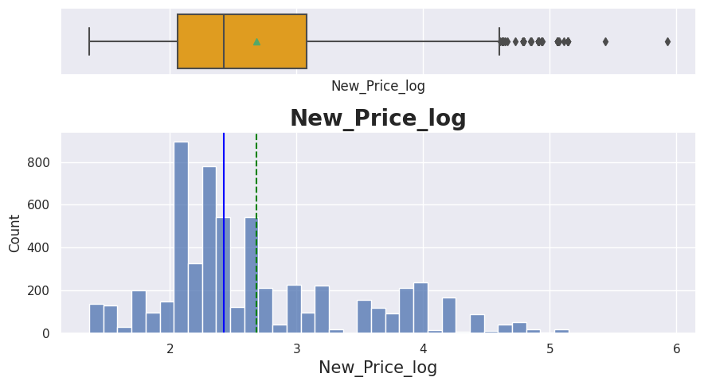

```python
histbox(cars, 'New_Price_log',figsize=(9, 5))
```

**Observations:** New_Price_Log after the log transformation is better scaled than New_Price.

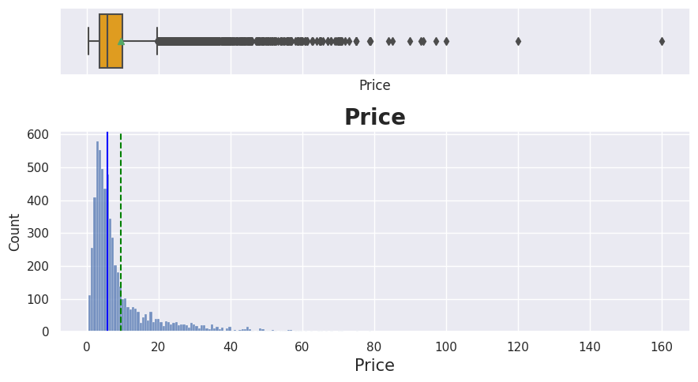

```python
histbox(cars, 'Price',figsize=(9, 5))
```

```python
# Examine outliers by looking at most expensive used cars.
top_highest_price_cars = cars.nlargest(2, 'Price')
print(top_highest_price_cars)
```

```
       Location  Year Fuel_Type Transmission Owner_Type  Mileage  Engine  \
4079  Hyderabad  2017    Diesel    Automatic      First   1333.0  2993.0
5781      Delhi  2011    Petrol    Automatic      Third     64.0  5204.0

      Power  Seats  Price        Brand  Kilometers_Driven_log  New_Price_log
4079  255.0    5.0  160.0   Land-Rover              10.126631       5.438079
5781   56.0    2.0  120.0  Lamborghini               8.779557       2.424803
```

**Observations:**

```python
# Using log transformation on the Price column to help with skewness
cars['Price_Log'] = np.log(cars['Price'])
```

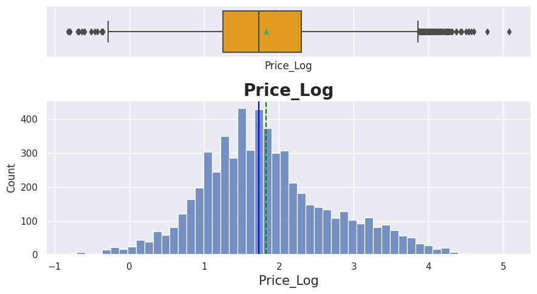

```python
histbox(cars, 'Price_Log',figsize=(9, 5))
```

**Oberservations:** The log transformation helped the distribution on the Price target variable. This should make our linear regression model perform better using Price_Log instead of Price. We will include Price_Log as the target variable for our Model-2 regression test to verfity this theory.

## Bivariant Analysis

```python
cars.info()
```

```
<class 'pandas.core.frame.DataFrame'>
RangeIndex: 6019 entries, 0 to 6018
Data columns (total 14 columns):
 #   Column                 Non-Null Count  Dtype
---  ------                 --------------  -----
 0   Location               6019 non-null   object
 1   Year                   6019 non-null   int64
 2   Fuel_Type              6019 non-null   object
 3   Transmission           6019 non-null   object
 4   Owner_Type             6019 non-null   object
 5   Mileage                6019 non-null   float64
 6   Engine                 6019 non-null   float64
 7   Power                  6019 non-null   float64
 8   Seats                  6019 non-null   float64
 9   Price                  6019 non-null   float64
 10  Brand                  6019 non-null   category
 11  Kilometers_Driven_log  6019 non-null   float64
 12  New_Price_log          6019 non-null   float64
 13  Price_Log              6019 non-null   float64
dtypes: category(1), float64(8), int64(1), object(4)
memory usage: 618.6+ KB
```

**Oberservatoins:** All of the expected log columns are now in the dataset

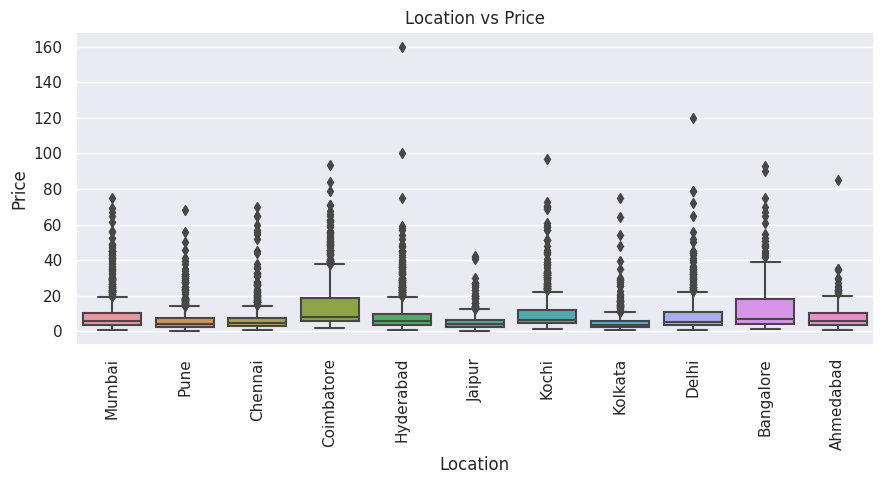

```python
# Visualize Location vs Price
plt.figure(figsize=(9, 5))
sns.boxplot(x='Location', y='Price', data=cars)
plt.xlabel('Location')
plt.ylabel('Price')
plt.title('Location vs Price')
plt.xticks(rotation=90)
plt.tight_layout()
plt.show()
```

**Observation:** 11 different location types. We will create use one-hot-encoding on the Location feature.

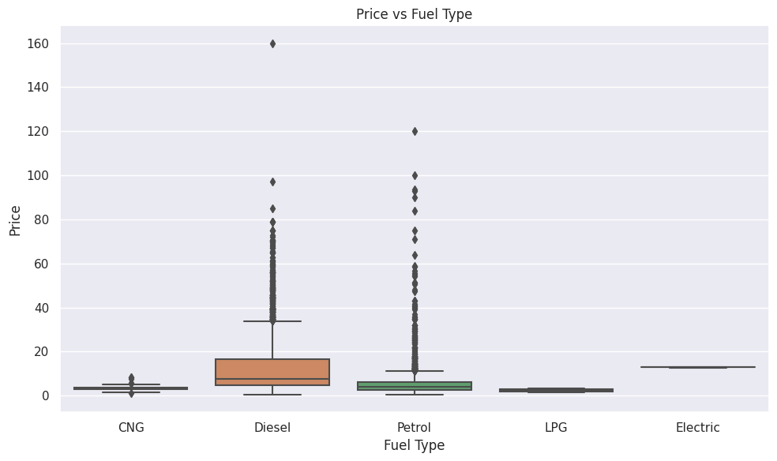

```python
# Visualize Price vs Fuel Type
plt.figure(figsize=(10, 6))
sns.boxplot(x='Fuel_Type', y='Price', data=cars)
plt.xlabel('Fuel Type')
plt.ylabel('Price')
plt.title('Price vs Fuel Type')
plt.tight_layout()
plt.show()
```

**Observation:** 5 different Fuel Type categories. We will create use one-hot-encoding on the Fuel_Type feature.

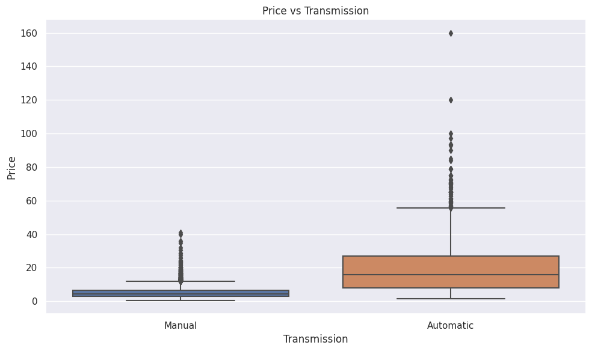

```python
# Visualize Price vs Transmission
plt.figure(figsize=(10, 6))
sns.boxplot(x='Transmission', y='Price', data=cars)
plt.xlabel('Transmission')
plt.ylabel('Price')
plt.title('Price vs Transmission')
plt.tight_layout()
plt.show()
```

**Observation:** Automatic and Manual Transmission types. We will create use one-hot-encoding on the Transmission feature.

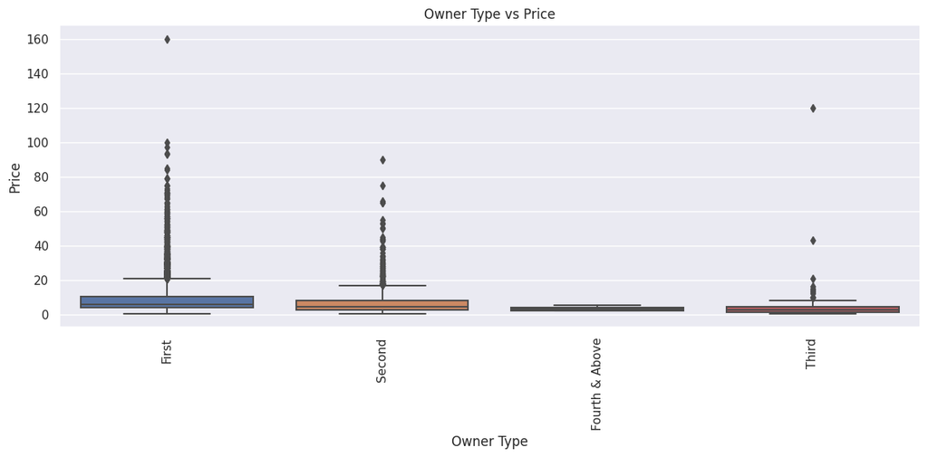

```python
# Visualize Price vs Owner Type
plt.figure(figsize=(12, 6))
sns.boxplot(x='Owner_Type', y='Price', data=cars)
plt.xlabel('Owner Type')
plt.ylabel('Price')
plt.title('Owner Type vs Price')
plt.xticks(rotation=90)
plt.tight_layout()
plt.show()
```

**Observation:** 4 owner types for this category. We will create use one-hot-encoding on the Owner_Type feature.

## Creating dummy variables using one-hot-encoding on our non-numeric features

```python
# Using one-hot-encoding to create dummies for all of the object datatype features
# Select the object columns for creating dummies
object_columns = cars.select_dtypes(include=['object', 'category']).columns

# Create dummies for the object columns
dummy_df = pd.get_dummies(cars[object_columns])

# Concatenate the dummy variables with the original DataFrame
cars = pd.concat([cars, dummy_df], axis=1)

# Drop the original object columns
cars.drop(object_columns, axis=1, inplace=True)
```

```python
cars.info()
```

```
<class 'pandas.core.frame.DataFrame'>
RangeIndex: 6019 entries, 0 to 6018
Data columns (total 63 columns):
 #   Column                     Non-Null Count  Dtype
---  ------                     --------------  -----
 0   Year                       6019 non-null   int64
 1   Mileage                    6019 non-null   float64
 2   Engine                     6019 non-null   float64
 3   Power                      6019 non-null   float64
 4   Seats                      6019 non-null   float64
 5   Price                      6019 non-null   float64
 6   Kilometers_Driven_log      6019 non-null   float64
 7   New_Price_log              6019 non-null   float64
 8   Price_Log                  6019 non-null   float64
 9   Location_Ahmedabad         6019 non-null   uint8
```

[output cut: 55 more lines]

**Here's a look at our meta data after dummy variables created. We see the encoded columns for the category features. The Price_Log column is created after the log transformation on Price.**

## Model Building Function for Linear Regression

**Define a linear regression function that accepts a dataframe, target_variable and model_name.**

**Then use it to build 2 models: One using Price (Model-1) and one using Price_Log (Model-2).**

```python
def build_regression_model(df, target_variable, model_name):
    # Create X and y
    X = df.drop(target_variable, axis=1)
    y = df[target_variable]

    # Split the data into train and test sets
    x_train, x_test, y_train, y_test = train_test_split(X, y, test_size=0.3, random_state=1)

    # Fit the linear regression model
    lin_reg_model = LinearRegression()
    lin_reg_model.fit(x_train, y_train)

    # Make predictions on the test set
    y_pred = lin_reg_model.predict(x_test)

    # Calculate performance metrics
    r2 = r2_score(y_test, y_pred)
    mse = mean_squared_error(y_test, y_pred)
    mae = mean_absolute_error(y_test, y_pred)
    rmse = np.sqrt(mse)
    mask = y_test != 0 #excluding zero in y_test for MAPE calcuation
    mape = np.mean(np.abs((y_test[mask] - y_pred[mask]) / y_test[mask])) * 100

    # Calculate adjusted R-squared
    n = len(x_test)
    p = x_test.shape[1]
    adjusted_r2 = 1 - (1 - r2) * (n - 1) / (n - p - 1)

    # Create a DataFrame with the performance metrics
    performance_metrics = pd.DataFrame({
        'Metric': ['R2 Score', 'Mean Squared Error', 'Mean Absolute Error',
                   'Root Mean Squared Error', 'Mean Absolute Percentage Error', 'Adjusted R2'],
        'Value': [r2, mse, mae, rmse, mape, adjusted_r2]
    })

    # Round the performance metric values to 2 decimal places
    performance_metrics['Value'] = performance_metrics['Value'].round(2)

    print(f"Performance metrics for Linear Regression {model_name} using {target_variable}:")
    print(tabulate(performance_metrics, headers='keys', tablefmt='grid', showindex=False))

    return lin_reg_model
```

```python
# For Model building we will prepare 2 datasets to adjust the target variables accordingly.
# We will remove 'Price_Log' from cars and remove 'Price' from cars_log
cars_price = cars.drop('Price_Log', axis=1)
cars_price_log = cars.drop('Price', axis=1)
```

## Model Performance Comparison between Model-1 (Price) and Model-2 (Price_Log)

```python
# Call the linear regression model function using cars data with Price for Model-1 and Price_Log for Model-2
model_1 = build_regression_model(cars_price, 'Price', 'Model-1')
print("\n")
model_2 = build_regression_model(cars_price_log, 'Price_Log', 'Model-2')
```

```
Performance metrics for Linear Regression Model-1 using Price:
+--------------------------------+---------+
| Metric                         |   Value |
+================================+=========+
| R2 Score                       |    0.82 |
+--------------------------------+---------+
| Mean Squared Error             |   21.31 |
+--------------------------------+---------+
| Mean Absolute Error            |    2.77 |
+--------------------------------+---------+
| Root Mean Squared Error        |    4.62 |
+--------------------------------+---------+
| Mean Absolute Percentage Error |   56.91 |
+--------------------------------+---------+
| Adjusted R2                    |    0.81 |
+--------------------------------+---------+


Performance metrics for Linear Regression Model-2 using Price_Log:
+--------------------------------+---------+
| Metric                         |   Value |
+================================+=========+
| R2 Score                       |    0.94 |
+--------------------------------+---------+
| Mean Squared Error             |    0.05 |
+--------------------------------+---------+
| Mean Absolute Error            |    0.16 |
+--------------------------------+---------+
| Root Mean Squared Error        |    0.21 |
+--------------------------------+---------+
| Mean Absolute Percentage Error |   16.45 |
+--------------------------------+---------+
| Adjusted R2                    |    0.94 |
+--------------------------------+---------+
```

**Model-2 using Price_Log as the target variable had much better performance metrics than Model-1 that used Price as the target variable.**

**The results of Model-2 are explained below:**

**R2 Score:** The R2 score of 0.94 indicates that approximately 94% of the variance in the target variable is explained by the model. This implies that the model captures a significant amount of the variability in the data and provides a good fit.

**Mean Squared Error (MSE):** The MSE value of 0.05 represents the average squared difference between the predicted and actual values. A lower MSE indicates that, on average, the model's predictions are close to the actual values, suggesting good accuracy.

**Root Mean Squared Error (RMSE):** The RMSE value of 0.21 provides an interpretable measure of the average magnitude of the prediction errors in the same units as the target variable. A lower RMSE indicates smaller average prediction errors, suggesting good accuracy.

**Mean Absolute Percentage Error (MAPE):** The MAPE is 16.45, which represents the average percentage difference between the predicted and actual values of 'Price_Log'.

**Adjusted R2:** The adjusted R2 value of 0.94 accounts for the number of predictors in the model. It suggests that the model's predictive power remains strong even after considering the number of predictors.

**Overall, based on these metrics, the model demonstrates good performance with high R2 score, low MSE, MAE, RMSE and MAPE values. These results indicate that the model has a good fit to the data and provides accurate predictions.**

**Using Model-2, Cars4U will have a reliable model for predicting and calculating what price to use for their cars.**

## Perform a review of Model-2's Coefficients to view which features Impact Price both positively and negatively

**- A Positive Coefficient means an increase in that Feature will increase the Price.**

**- A Negative Coefficient means an increase in that Feature will decrease the price.**

```python
p# Define a function to calculate and display the Positive and Negative Coefficients that impact the Price of used car.
def show_impact_features(df, target_variable, model_name):
    # Create X and y
    X = df.drop(target_variable, axis=1)
    y = df[target_variable]

    # Split the data into train and test sets
    x_train, x_test, y_train, y_test = train_test_split(X, y, test_size=0.3, random_state=1)

    # Fit the linear regression model
    lin_reg_model = LinearRegression()
    lin_reg_model.fit(x_train, y_train)

    # Retrieve the feature coefficients and names
    feature_coefficients = lin_reg_model.coef_
    feature_names = X.columns

    # Create a DataFrame to store the feature coefficients and their impact
    feature_impact = pd.DataFrame({
        'Feature': feature_names,
        'Coefficient': feature_coefficients
    })

    # Sort the DataFrame by the absolute coefficients in descending order
    feature_impact = feature_impact.reindex(feature_impact['Coefficient'].abs().sort_values(ascending=False).index)

    # Split the DataFrame into positive and negative features
    pos = feature_impact[feature_impact['Coefficient'] > 0]  # Adjust the number to display more or fewer features
    neg = feature_impact[feature_impact['Coefficient'] < 0]  # Adjust the number to display more or fewer features

    # Sort positive features by feature name ascending
    pos = pos.sort_values('Coefficient', ascending=False)
    pos.rename(columns={'Coefficient': 'Pos Coef_'}, inplace=True)

    # Sort negative features by feature name ascending
    neg = neg.sort_values('Coefficient', ascending=True)
    neg.rename(columns={'Coefficient': 'Neg Coef_'}, inplace=True)

    # Create a combined DataFrame with positive and negative features side by side
    pos = pos[['Feature', 'Pos Coef_']].dropna().reset_index(drop=True)
    neg = neg[['Feature', 'Neg Coef_']].dropna().reset_index(drop=True)
    pos_neg_features = pd.concat([pos, neg], axis=1)

    return pos_neg_features
```

```python
# Call the linear regression model function using cars data with Price for Model-1 and Price_Log for Model-2
price_impact = show_impact_features(cars_price_log, 'Price_Log', 'Model-2')
print("        Feature Coefficients illustrating their impact on Price")
price_impact.head(50)
```

```
        Feature Coefficients illustrating their impact on Price
```

|  | Feature | Pos Coef_ | Feature | Neg Coef_ |
| --- | --- | --- | --- | --- |
| 0 | Brand_Lamborghini | 2.427250 | Brand_Isuzu | -9.212734e-01 |
| 1 | Fuel_Type_Electric | 0.601955 | Brand_Tata | -5.602527e-01 |
| 2 | Brand_Mini | 0.527475 | Brand_Ambassador | -4.599227e-01 |
| 3 | New_Price_log | 0.415445 | Brand_Datsun | -4.131723e-01 |
| 4 | Brand_Bentley | 0.347145 | Brand_Chevrolet | -4.091481e-01 |
| 5 | Brand_Smart | 0.284303 | Brand_Fiat | -2.964309e-01 |
| 6 | Brand_Force | 0.207006 | Brand_Mahindra | -2.794516e-01 |
| 7 | Brand_Jaguar | 0.201280 | Brand_Skoda | -2.509423e-01 |
| 8 | Location_Bangalore | 0.171306 | Fuel_Type_CNG | -2.234030e-01 |
| 9 | Brand_Land-Rover | 0.156028 | Location_Kolkata | -2.223378e-01 |
| 10 | Brand_Mercedes-Benz | 0.132367 | Fuel_Type_Petrol | -2.156147e-01 |
| 11 | Brand_Audi | 0.119454 | Brand_Nissan | -1.752807e-01 |
| 12 | Location_Hyderabad | 0.119341 | Brand_Ford | -1.708334e-01 |
| 13 | Year | 0.117639 | Brand_Renault | -1.668420e-01 |
| 14 | Location_Coimbatore | 0.109065 | Brand_Mitsubishi | -1.503014e-01 |
| 15 | Brand_BMW | 0.107767 | Brand_Porsche | -1.477998e-01 |
| 16 | Brand_Jeep | 0.106318 | Brand_Volkswagen | -1.133160e-01 |
| 17 | Brand_Volvo | 0.103408 | Owner_Type_Third | -1.122878e-01 |
| 18 | Transmission_Automatic | 0.058524 | Fuel_Type_LPG | -1.091095e-01 |
| 19 | Owner_Type_First | 0.057309 | Brand_Hyundai | -8.281558e-02 |
| 20 | Owner_Type_Fourth & Above | 0.054208 | Kilometers_Driven_log | -6.848387e-02 |
| 21 | Location_Chennai | 0.043940 | Location_Delhi | -6.324952e-02 |
| 22 | Seats | 0.022983 | Transmission_Manual | -5.852388e-02 |
| 23 | Power | 0.001438 | Brand_Toyota | -5.807208e-02 |
| 24 | Owner_Type_Second | 0.000771 | Location_Jaipur | -5.698857e-02 |
| 25 | Engine | 0.000306 | Fuel_Type_Diesel | -5.382802e-02 |
| 26 | Location_Ahmedabad | 0.000080 | Brand_Honda | -5.347493e-02 |
| 27 | Mileage | 0.000004 | Location_Mumbai | -3.971035e-02 |
| 28 | NaN | NaN | Location_Pune | -3.212167e-02 |
| 29 | NaN | NaN | Location_Kochi | -2.932350e-02 |
| 30 | NaN | NaN | Brand_Maruti | -1.047239e-02 |
| 31 | NaN | NaN | Brand_Hindustan | -3.885781e-16 |
| 32 | NaN | NaN | Brand_OpelCorsa | -1.110223e-16 |